# Python Code Public Examples

# 4. The company gets leads from various channels such as print media, digital media, referrals, etc. Which of these channels have the highest lead conversion rate?

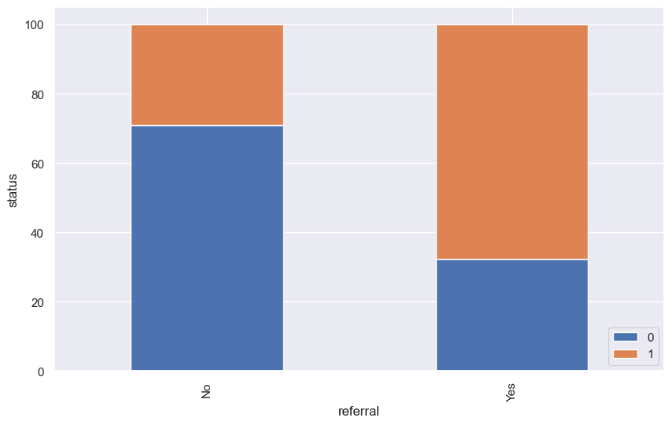

```python
stacked_barplot(data, "referral","status" )
```

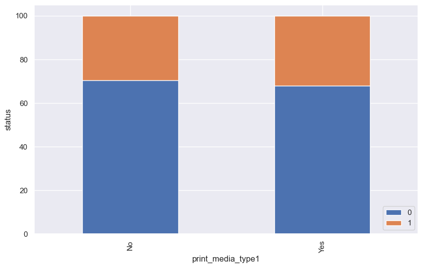

```python
stacked_barplot(data, "print_media_type1","status" )
```

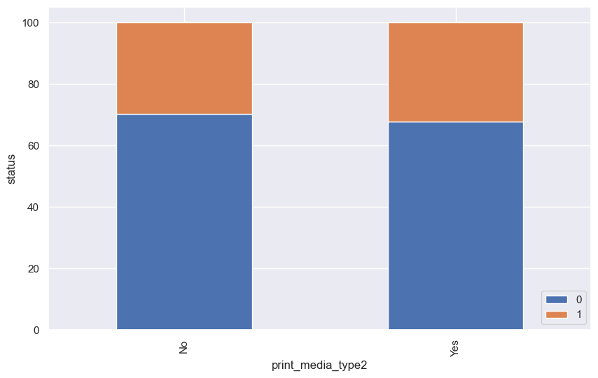

```python
stacked_barplot(data, "print_media_type2","status" )
```

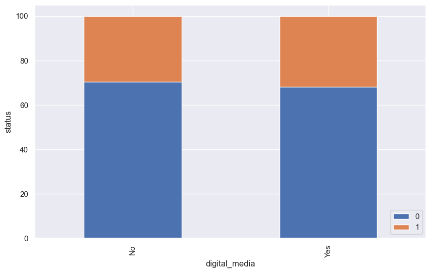

```python
stacked_barplot(data, "digital_media","status" )
```

# 5. People browsing the website or mobile application are generally required to create a profile by sharing their personal data before they can access additional information. Does having more details about a prospect increase the chances of conversion?

When the user enters personal data there is an indication of being more interested. But the final outcome is guess work as each individual is different.

## Data Preprocessing

- Missing value treatment (if needed)
- Feature engineering (if needed)
- Outlier detection and treatment (if needed)
- Preparing data for modeling
- Any other preprocessing steps (if needed)

```python
# Step 1: Identify categorical and numerical columns
categorical_columns = ['current_occupation', 'first_interaction', 'profile_completed', 'last_activity', 'print_media_type1',
                       'print_media_type2', 'digital_media', 'educational_channels', 'referral']
numerical_columns = ['age', 'website_visits', 'time_spent_on_website', 'page_views_per_visit']

# Step 2: Create preprocessing pipelines
categorical_pipeline = Pipeline(steps=[
    ('imputer', SimpleImputer(strategy='most_frequent')),  # Handle missing categorical data
    ('encoder', OneHotEncoder(handle_unknown='ignore'))  # One-hot encode categorical data
])

numerical_pipeline = Pipeline(steps=[
    ('imputer', SimpleImputer(strategy='mean')),  # Handle missing numerical data
    ('scaler', StandardScaler())  # Standardize numerical data
])

# Combine both pipelines
preprocessor = ColumnTransformer(transformers=[
    ('num', numerical_pipeline, numerical_columns),
    ('cat', categorical_pipeline, categorical_columns)
])

# Step 3: Apply preprocessing to the entire dataset
X = data.drop(columns='status')
y = data['status']
X_processed = preprocessor.fit_transform(X)

# Step 4: Split the preprocessed data into train and test sets
X_train, X_test, y_train, y_test = train_test_split(X_processed, y, test_size=0.30, random_state=1, stratify=y)
```

## EDA

- It is a good idea to explore the data once again after manipulating it.

```python
data.head(3)
```

|  | age | current_occupation | first_interaction | profile_completed | website_visits | time_spent_on_website | page_views_per_visit | last_activity | print_media_type1 | print_media_type2 | digital_media | educational_channels | referral | status |
| --- | --- | --- | --- | --- | --- | --- | --- | --- | --- | --- | --- | --- | --- | --- |
| 0 | 57 | Unemployed | Website | High | 7 | 1639 | 1 | Website Activity | Yes | No | Yes | No | No | 1 |
| 1 | 56 | Professional | Mobile App | Medium | 2 | 83 | 0 | Website Activity | No | No | No | Yes | No | 0 |
| 2 | 52 | Professional | Website | Medium | 3 | 330 | 0 | Website Activity | No | No | Yes | No | No | 0 |

## Building a Decision Tree model

```python
# Initialize the Decision Tree Classifier
dt_model = DecisionTreeClassifier(random_state=1)

# Fit the model on the training data
dt_model.fit(X_train, y_train)

# Make predictions on the test data
y_pred = dt_model.predict(X_test)

# Evaluate the model
accuracy = accuracy_score(y_test, y_pred)
print("Decision Tree Classifier Accuracy:", accuracy)
print("\nClassification Report:\n", classification_report(y_test, y_pred))
```

```
Decision Tree Classifier Accuracy: 0.7955202312138728

Classification Report:
               precision    recall  f1-score   support

           0       0.86      0.84      0.85       971
           1       0.65      0.69      0.67       413

    accuracy                           0.80      1384
   macro avg       0.76      0.76      0.76      1384
weighted avg       0.80      0.80      0.80      1384
```